# MAKING A MOVIE WHO SHOULD WE HIRE 🧐

In this data analysis project, we delve into the movie dataset sourced from I. Joly & P. Lemaire. Our approach follows the CRISP-DM methodology. The results obtained provide valuable insights, shaping decisions and strategies in the realm of filmmaking.

# I. Business understanding

# II. Data understanding

| No. | Parameter | Description |
| --- | --- | --- |
| 1 | movie_title | Title of the movie |
| 2 | actor_1_name | Primary actor starring in the movie |
| 3 | imdb_score | IMDB Score of the movie on IMDB, rated by the users |
| 4 | genres | Film categorization |
| 5 | ROI_perc | ROI = profit / budget |

# III. Data preparation

## General Movie.Data

Import these libraries to run this R.script of this project

| No. | Lib Name | Description |
| --- | --- | --- |
| 1 | rmdformats | Custom R Markdown formats and templates |
| 2 | skimr | Summarizes data frames and vectors |
| 3 | readr | Reads flat files (e.g., CSV, TSV) |
| 4 | dplyr | Data manipulation and transformation |
| 5 | anytime | Converts dates and times |
| 6 | gt | Generates tables with the gt package |
| 7 | magrittr | Provides the pipe operator %>% |
| 8 | ggplot2 | Data visualization with ggplot2 |
| 9 | stringr | String manipulation functions |

Data loading

```r
movies_data <- load("Movie.Data_Complete.RData")
```

General View of the Dataset

| color | director_name | num_critic_for_reviews | duration | director_facebook_likes | actor_3_facebook_likes | actor_2_name | actor_1_facebook_likes | gross | genres | actor_1_name | movie_title | num_voted_users | cast_total_facebook_likes | actor_3_name | facenumber_in_poster | plot_keywords | movie_imdb_link | num_user_for_reviews | language | country | content_rating | budget | title_year | actor_2_facebook_likes | imdb_score | aspect_ratio | movie_facebook_likes | profit | ROI_perc |
| --- | --- | --- | --- | --- | --- | --- | --- | --- | --- | --- | --- | --- | --- | --- | --- | --- | --- | --- | --- | --- | --- | --- | --- | --- | --- | --- | --- | --- | --- |
| Color | James Cameron | 723 | 178 | 0 | 855 | Joel David Moore | 1000 | 760505847 | Action\|Adventure\|Fantasy\|Sci-Fi | CCH Pounder | Avatar | 886204 | 4834 | Wes Studi | 0 | avatar\|future\|marine\|native\|paraplegic | http://www.imdb.com/title/tt0499549/?ref_=fn_tt_tt_1 | 3054 | English | USA | PG-13 | 237000000 | 2009 | 936 | 7.9 | 1.78 | 33000 | 523505847 | 220.888543 |
| Color | Gore Verbinski | 302 | 169 | 563 | 1000 | Orlando Bloom | 40000 | 309404152 | Action\|Adventure\|Fantasy | Johnny Depp | Pirates of the Caribbean: At World's End | 471220 | 48350 | Jack Davenport | 0 | goddess\|marriage ceremony\|marriage proposal\|pirate\|singapore | http://www.imdb.com/title/tt0449088/?ref_=fn_tt_tt_1 | 1238 | English | USA | PG-13 | 300000000 | 2007 | 5000 | 7.1 | 2.35 | 0 | 9404152 | 3.134717 |
| Color | Sam Mendes | 602 | 148 | 0 | 161 | Rory Kinnear | 11000 | 200074175 | Action\|Adventure\|Thriller | Christoph Waltz | Spectre | 275868 | 11700 | Stephanie Sigman | 1 | bomb\|espionage\|sequel\|spy\|terrorist | http://www.imdb.com/title/tt2379713/?ref_=fn_tt_tt_1 | 994 | English | UK | PG-13 | 245000000 | 2015 | 393 | 6.8 | 2.35 | 85000 | -44925825 | -18.337071 |
| Color | Christopher Nolan | 813 | 164 | 22000 | 23000 | Christian Bale | 27000 | 448130642 | Action\|Thriller | Tom Hardy | The Dark Knight Rises | 1144337 | 106759 | Joseph Gordon-Levitt | 0 | deception\|imprisonment\|lawlessness\|police officer\|terrorist plot | http://www.imdb.com/title/tt1345836/?ref_=fn_tt_tt_1 | 2701 | English | USA | PG-13 | 250000000 | 2012 | 23000 | 8.5 | 2.35 | 164000 | 198130642 | 79.252257 |
|  | Doug Walker | NA | NA | 131 | NA | Rob Walker | 131 | NA | Documentary | Doug Walker | Star Wars: Episode VII - The Force Awakens | 8 | 143 |  | 0 |  | http://www.imdb.com/title/tt5289954/?ref_=fn_tt_tt_1 | NA |  |  |  | NA | NA | 12 | 7.1 | NA | 0 | NA | NA |
| Color | Andrew Stanton | 462 | 132 | 475 | 530 | Samantha Morton | 640 | 73058679 | Action\|Adventure\|Sci-Fi | Daryl Sabara | John Carter | 212204 | 1873 | Polly Walker | 1 | alien\|american civil war\|male nipple\|mars\|princess | http://www.imdb.com/title/tt0401729/?ref_=fn_tt_tt_1 | 738 | English | USA | PG-13 | 263700000 | 2012 | 632 | 6.6 | 2.35 | 24000 | -190641321 | -72.294775 |

Displaying summary statistics

```r
Movie.Data %>% summary() %>% kable() %>% head()
```

[output not shown]

## Specific data for project

| No. | Genres | Count |
| --- | --- | --- |
| 1 | Drama | 2533 |
| 2 | Comedy | 1847 |
| 3 | Thriller | 1364 |
| 4 | Action | 1113 |
| 5 | Romance | 1084 |
| 6 | Adventure | 888 |
| 7 | Crime | 868 |
| 8 | Sci-Fi | 594 |
| 9 | Fantasy | 583 |
| 10 | Horror | 539 |

Create dataset for the project called “selected_genres_subset”

Selected Genres Subset

Subset of Movies with Selected Genres and Specific Columns

| movie_title | actor_1_name | genres | ROI_perc | imdb_score |
| --- | --- | --- | --- | --- |
| Avatar | CCH Pounder | Action\|Adventure\|Fantasy\|Sci-Fi | 220.888543 | 7.9 |
| Pirates of the Caribbean: At World's End | Johnny Depp | Action\|Adventure\|Fantasy | 3.134717 | 7.1 |
| Spectre | Christoph Waltz | Action\|Adventure\|Thriller | -18.337071 | 6.8 |
| The Dark Knight Rises | Tom Hardy | Action\|Thriller | 79.252257 | 8.5 |
| John Carter | Daryl Sabara | Action\|Adventure\|Sci-Fi | -72.294775 | 6.6 |
| Spider-Man 3 | J.K. Simmons | Action\|Adventure\|Romance | 30.438102 | 6.2 |

```
## [1] "|   |movie_title      |actor_1_name     |   genres        |   ROI_perc      |  imdb_score  |"
## [2] "|:--|:----------------|:----------------|:----------------|:----------------|:-------------|"
## [3] "|   |Length:4563      |Length:4563      |Length:4563      |Min.   : -100.00 |Min.   :1.700 |"
## [4] "|   |Class :character |Class :character |Class :character |1st Qu.:  -55.60 |1st Qu.:5.800 |"
## [5] "|   |Mode  :character |Mode  :character |Mode  :character |Median :    5.23 |Median :6.600 |"
## [6] "|   |NA               |NA               |NA               |Mean   :  183.09 |Mean   :6.443 |"
```

Check for missing values in the data

```
##  movie_title actor_1_name       genres     ROI_perc   imdb_score
##            0            0            0          994            0
```

We going to remove 994 NA value ROI (because we also check about the profit it have same NA value so that we couldn’t cal the ROI)

```
## [1] "|   |movie_title      |actor_1_name     |   genres        |   ROI_perc      |  imdb_score  |"
## [2] "|:--|:----------------|:----------------|:----------------|:----------------|:-------------|"
## [3] "|   |Length:3569      |Length:3569      |Length:3569      |Min.   : -100.00 |Min.   :1.900 |"
## [4] "|   |Class :character |Class :character |Class :character |1st Qu.:  -55.60 |1st Qu.:5.900 |"
## [5] "|   |Mode  :character |Mode  :character |Mode  :character |Median :    5.23 |Median :6.600 |"
## [6] "|   |NA               |NA               |NA               |Mean   :  183.09 |Mean   :6.463 |"
```

| No. | Genres | Count |
| --- | --- | --- |
| 1 | Drama | 1913 |
| 2 | Comedy | 1491 |
| 3 | Thriller | 1087 |
| 4 | Action | 935 |
| 5 | Romance | 868 |

Now we separate into 5 small table

```
## <environment: R_GlobalEnv>
```

Drama Genres Subset

| movie_title | actor_1_name | genres | ROI_perc | imdb_score |
| --- | --- | --- | --- | --- |
| Robin Hood | Mark Addy | Action\|Adventure\|Drama\|History | -47.390132 | 6.7 |
| King Kong | Naomi Watts | Action\|Adventure\|Drama\|Romance | 5.338773 | 7.2 |
| Titanic | Leonardo DiCaprio | Drama\|Romance | 229.336151 | 7.7 |
| The Great Gatsby | Leonardo DiCaprio | Drama\|Romance | 37.916949 | 7.3 |
| A Christmas Carol | Robin Wright | Animation\|Drama\|Family\|Fantasy | -31.074952 | 6.8 |
| The Legend of Tarzan | Christoph Waltz | Action\|Adventure\|Drama\|Romance | -31.082356 | 6.6 |

```
## [1] "|   |movie_title      |actor_1_name     |   genres        |   ROI_perc      |  imdb_score  |"
## [2] "|:--|:----------------|:----------------|:----------------|:----------------|:-------------|"
## [3] "|   |Length:1913      |Length:1913      |Length:1913      |Min.   :  -99.99 |Min.   :2.100 |"
## [4] "|   |Class :character |Class :character |Class :character |1st Qu.:  -66.92 |1st Qu.:6.300 |"
## [5] "|   |Mode  :character |Mode  :character |Mode  :character |Median :   -5.59 |Median :6.900 |"
## [6] "|   |NA               |NA               |NA               |Mean   :  190.78 |Mean   :6.788 |"
```

Comedy Genres Subset

| movie_title | actor_1_name | genres | ROI_perc | imdb_score |
| --- | --- | --- | --- | --- |
| Tangled | Brad Garrett | Adventure\|Animation\|Comedy\|Family\|Fantasy\|Musical\|Romance | -22.766438 | 7.8 |
| Men in Black 3 | Will Smith | Action\|Adventure\|Comedy\|Family\|Fantasy\|Sci-Fi | -20.435176 | 6.8 |
| Monsters University | Steve Buscemi | Adventure\|Animation\|Comedy\|Family\|Fantasy | 34.244165 | 7.3 |
| Cars 2 | Joe Mantegna | Adventure\|Animation\|Comedy\|Family\|Sport | -4.274563 | 6.3 |
| Toy Story 3 | Tom Hanks | Adventure\|Animation\|Comedy\|Family\|Fantasy | 107.492249 | 8.3 |
| Brave | Kelly Macdonald | Adventure\|Animation\|Comedy\|Family\|Fantasy | 28.260639 | 7.2 |

```
## [1] "|   |movie_title      |actor_1_name     |   genres        |   ROI_perc      |  imdb_score  |"
## [2] "|:--|:----------------|:----------------|:----------------|:----------------|:-------------|"
## [3] "|   |Length:1491      |Length:1491      |Length:1491      |Min.   :  -99.99 |Min.   :1.900 |"
## [4] "|   |Class :character |Class :character |Class :character |1st Qu.:  -46.17 |1st Qu.:5.600 |"
## [5] "|   |Mode  :character |Mode  :character |Mode  :character |Median :   19.22 |Median :6.300 |"
## [6] "|   |NA               |NA               |NA               |Mean   :  189.43 |Mean   :6.183 |"
```

Thriller Genres Subset

| movie_title | actor_1_name | genres | ROI_perc | imdb_score |
| --- | --- | --- | --- | --- |
| Spectre | Christoph Waltz | Action\|Adventure\|Thriller | -18.33707 | 6.8 |
| The Dark Knight Rises | Tom Hardy | Action\|Thriller | 79.25226 | 8.5 |
| Battleship | Liam Neeson | Action\|Adventure\|Sci-Fi\|Thriller | -68.81667 | 5.9 |
| Jurassic World | Bryce Dallas Howard | Action\|Adventure\|Sci-Fi\|Thriller | 334.78485 | 7.0 |
| Skyfall | Albert Finney | Action\|Adventure\|Thriller | 52.18014 | 7.8 |
| X-Men: The Last Stand | Hugh Jackman | Action\|Adventure\|Fantasy\|Sci-Fi\|Thriller | 11.60001 | 6.8 |

```
## [1] "|   |movie_title      |actor_1_name     |   genres        |   ROI_perc      |  imdb_score  |"
## [2] "|:--|:----------------|:----------------|:----------------|:----------------|:-------------|"
## [3] "|   |Length:1087      |Length:1087      |Length:1087      |Min.   : -100.00 |Min.   :2.700 |"
## [4] "|   |Class :character |Class :character |Class :character |1st Qu.:  -55.95 |1st Qu.:5.800 |"
## [5] "|   |Mode  :character |Mode  :character |Mode  :character |Median :    0.06 |Median :6.400 |"
## [6] "|   |NA               |NA               |NA               |Mean   :  189.47 |Mean   :6.372 |"
```

Action Genres Subset

| movie_title | actor_1_name | genres | ROI_perc | imdb_score |
| --- | --- | --- | --- | --- |
| Avatar | CCH Pounder | Action\|Adventure\|Fantasy\|Sci-Fi | 220.888543 | 7.9 |
| Pirates of the Caribbean: At World's End | Johnny Depp | Action\|Adventure\|Fantasy | 3.134717 | 7.1 |
| Spectre | Christoph Waltz | Action\|Adventure\|Thriller | -18.337071 | 6.8 |
| The Dark Knight Rises | Tom Hardy | Action\|Thriller | 79.252257 | 8.5 |
| John Carter | Daryl Sabara | Action\|Adventure\|Sci-Fi | -72.294775 | 6.6 |
| Spider-Man 3 | J.K. Simmons | Action\|Adventure\|Romance | 30.438102 | 6.2 |

```
## [1] "|   |movie_title      |actor_1_name     |   genres        |   ROI_perc       |  imdb_score  |"
## [2] "|:--|:----------------|:----------------|:----------------|:-----------------|:-------------|"
## [3] "|   |Length:935       |Length:935       |Length:935       |Min.   :  -99.998 |Min.   :2.100 |"
## [4] "|   |Class :character |Class :character |Class :character |1st Qu.:  -52.777 |1st Qu.:5.700 |"
## [5] "|   |Mode  :character |Mode  :character |Mode  :character |Median :   -5.783 |Median :6.300 |"
## [6] "|   |NA               |NA               |NA               |Mean   :   80.203 |Mean   :6.286 |"
```

Romance Genres Subset

| movie_title | actor_1_name | genres | ROI_perc | imdb_score |
| --- | --- | --- | --- | --- |
| Spider-Man 3 | J.K. Simmons | Action\|Adventure\|Romance | 30.438102 | 6.2 |
| Tangled | Brad Garrett | Adventure\|Animation\|Comedy\|Family\|Fantasy\|Musical\|Romance | -22.766438 | 7.8 |
| King Kong | Naomi Watts | Action\|Adventure\|Drama\|Romance | 5.338773 | 7.2 |
| Titanic | Leonardo DiCaprio | Drama\|Romance | 229.336151 | 7.7 |
| Spider-Man 2 | J.K. Simmons | Action\|Adventure\|Fantasy\|Romance | 86.688947 | 7.3 |
| The Great Gatsby | Leonardo DiCaprio | Drama\|Romance | 37.916949 | 7.3 |

```
## [1] "|   |movie_title      |actor_1_name     |   genres        |   ROI_perc      |  imdb_score  |"
## [2] "|:--|:----------------|:----------------|:----------------|:----------------|:-------------|"
## [3] "|   |Length:868       |Length:868       |Length:868       |Min.   :  -99.99 |Min.   :2.100 |"
## [4] "|   |Class :character |Class :character |Class :character |1st Qu.:  -53.31 |1st Qu.:5.900 |"
## [5] "|   |Mode  :character |Mode  :character |Mode  :character |Median :   15.74 |Median :6.500 |"
## [6] "|   |NA               |NA               |NA               |Mean   :  230.73 |Mean   :6.424 |"
```

# IV. Modeling based on imdb_score

## Drama Table

Check in each genres_table that if actor_1_name appear less than 5 times remove that line out of table

| movie_title | actor_1_name | genres | ROI_perc | imdb_score |
| --- | --- | --- | --- | --- |
| King Kong | Naomi Watts | Action\|Adventure\|Drama\|Romance | 5.338773 | 7.2 |
| Titanic | Leonardo DiCaprio | Drama\|Romance | 229.336151 | 7.7 |
| The Great Gatsby | Leonardo DiCaprio | Drama\|Romance | 37.916949 | 7.3 |
| A Christmas Carol | Robin Wright | Animation\|Drama\|Family\|Fantasy | -31.074952 | 6.8 |
| The Dark Knight | Christian Bale | Action\|Crime\|Drama\|Thriller | 188.278952 | 9.0 |
| Hugo | Chloë Grace Moretz | Adventure\|Drama\|Family\|Mystery | -56.576415 | 7.5 |

```
## [1] "|   |movie_title      |actor_1_name     |   genres        |   ROI_perc       |  imdb_score  |"
## [2] "|:--|:----------------|:----------------|:----------------|:-----------------|:-------------|"
## [3] "|   |Length:724       |Length:724       |Length:724       |Min.   :  -99.990 |Min.   :3.100 |"
## [4] "|   |Class :character |Class :character |Class :character |1st Qu.:  -51.544 |1st Qu.:6.500 |"
## [5] "|   |Mode  :character |Mode  :character |Mode  :character |Median :    8.583 |Median :7.000 |"
## [6] "|   |NA               |NA               |NA               |Mean   :  129.488 |Mean   :6.947 |"
```

```
## But in 724 rows, it actually only 75 actors.
```

Cal the actor imdb

Actor ranking Table

| actor_1_name | imdb_actor | ranking |
| --- | --- | --- |
| Clint Eastwood | 7.600000 | 1 |
| Leonardo DiCaprio | 7.525000 | 2 |
| Tom Hanks | 7.505882 | 3 |
| Hugh Jackman | 7.416667 | 4 |
| Christian Bale | 7.331250 | 5 |
| Kevin Spacey | 7.329412 | 6 |

Create bar chart

[figure not shown]

```r
# Create a bar chart with scaled y-axis and rotated x-axis labels
bar_chart_scaled <- ggplot(actor_ranking_table, aes(x = actor_1_name, y = imdb_actor, fill = factor(ranking))) +
  geom_bar(stat = "identity", position = "dodge", width = 0.7) +
  geom_text(aes(label = sprintf("%.2f", imdb_actor), y = imdb_actor), vjust = -0.5) +  # Add value labels
  scale_fill_viridis_d() +
  labs(
    title = "Actor IMDb Scores and Rankings on Drama genres",
    x = "Actor Name",
    y = "Average IMDb Score",
    fill = "Ranking"
  ) +
  theme_minimal() +
  coord_cartesian(ylim = c(6, 8)) +  # Set y-axis limit
  theme(axis.text.x = element_text(angle = 45, hjust = 1))  # Rotate x-axis labels

# Display the scaled bar chart
print(bar_chart_scaled)
```

## Comedy Table

Check in each genres_table that if actor_1_name appear less than 5 times remove that line out of table

| movie_title | actor_1_name | genres | ROI_perc | imdb_score |
| --- | --- | --- | --- | --- |
| Men in Black 3 | Will Smith | Action\|Adventure\|Comedy\|Family\|Fantasy\|Sci-Fi | -20.435176 | 6.8 |
| Monsters University | Steve Buscemi | Adventure\|Animation\|Comedy\|Family\|Fantasy | 34.244165 | 7.3 |
| Toy Story 3 | Tom Hanks | Adventure\|Animation\|Comedy\|Family\|Fantasy | 107.492249 | 8.3 |
| Monsters vs. Aliens | Amy Poehler | Action\|Adventure\|Animation\|Comedy\|Family\|Sci-Fi | 13.332645 | 6.5 |
| Wild Wild West | Will Smith | Action\|Comedy\|Sci-Fi\|Western | -33.090936 | 4.8 |
| Suicide Squad | Will Smith | Action\|Adventure\|Comedy\|Sci-Fi | -7.950181 | 6.9 |

```
## [1] "|   |movie_title      |actor_1_name     |   genres        |   ROI_perc     |  imdb_score  |"
## [2] "|:--|:----------------|:----------------|:----------------|:---------------|:-------------|"
## [3] "|   |Length:526       |Length:526       |Length:526       |Min.   : -99.93 |Min.   :2.700 |"
## [4] "|   |Class :character |Class :character |Class :character |1st Qu.: -32.63 |1st Qu.:5.800 |"
## [5] "|   |Mode  :character |Mode  :character |Mode  :character |Median :  29.78 |Median :6.400 |"
## [6] "|   |NA               |NA               |NA               |Mean   : 115.90 |Mean   :6.357 |"
```

```
## But in 526 rows, it actually only 68 actors.
```

Cal the actor imdb

Actor ranking Table

| actor_1_name | imdb_actor | ranking |
| --- | --- | --- |
| Tom Hanks | 7.358333 | 1 |
| Philip Seymour Hoffman | 7.300000 | 2 |
| Joseph Gordon-Levitt | 7.280000 | 3 |
| Minnie Driver | 7.040000 | 4 |
| Steve Carell | 7.000000 | 5 |
| Bill Murray | 6.947368 | 6 |

Create bar chart

[figure not shown]

```r
# Create a bar chart with scaled y-axis and rotated x-axis labels
bar_chart_scaled <- ggplot(actor_ranking_table, aes(x = actor_1_name, y = imdb_actor, fill = factor(ranking))) +
  geom_bar(stat = "identity", position = "dodge", width = 0.7) +
  geom_text(aes(label = sprintf("%.2f", imdb_actor), y = imdb_actor), vjust = -0.5) +  # Add value labels
  scale_fill_viridis_d() +
  labs(
    title = "Actor IMDb Scores and Rankings on Comedy genres",
    x = "Actor Name",
    y = "Average IMDb Score",
    fill = "Ranking"
  ) +
  theme_minimal() +
  coord_cartesian(ylim = c(6, 8)) +  # Set y-axis limit
  theme(axis.text.x = element_text(angle = 45, hjust = 1))  # Rotate x-axis labels

# Display the scaled bar chart
print(bar_chart_scaled)
```

## Thriller Table

Check in each genres_table that if actor_1_name appear less than 5 times remove that line out of table

| movie_title | actor_1_name | genres | ROI_perc | imdb_score |
| --- | --- | --- | --- | --- |
| The Dark Knight Rises | Tom Hardy | Action\|Thriller | 79.25226 | 8.5 |
| Battleship | Liam Neeson | Action\|Adventure\|Sci-Fi\|Thriller | -68.81667 | 5.9 |
| X-Men: The Last Stand | Hugh Jackman | Action\|Adventure\|Fantasy\|Sci-Fi\|Thriller | 11.60001 | 6.8 |
| Furious 7 | Jason Statham | Action\|Crime\|Thriller | 84.22848 | 7.2 |
| X-Men: Days of Future Past | Jennifer Lawrence | Action\|Adventure\|Fantasy\|Sci-Fi\|Thriller | 16.95749 | 8.0 |
| The Dark Knight | Christian Bale | Action\|Crime\|Drama\|Thriller | 188.27895 | 9.0 |

```
## [1] "|   |movie_title      |actor_1_name     |   genres        |   ROI_perc     |  imdb_score  |"
## [2] "|:--|:----------------|:----------------|:----------------|:---------------|:-------------|"
## [3] "|   |Length:371       |Length:371       |Length:371       |Min.   :-99.971 |Min.   :3.100 |"
## [4] "|   |Class :character |Class :character |Class :character |1st Qu.:-43.875 |1st Qu.:6.100 |"
## [5] "|   |Mode  :character |Mode  :character |Mode  :character |Median :  3.274 |Median :6.600 |"
## [6] "|   |NA               |NA               |NA               |Mean   : 28.831 |Mean   :6.622 |"
```

```
## But in 371 rows, it actually only 46 actors.
```

Cal the actor imdb

Actor ranking Table

| actor_1_name | imdb_actor | ranking |
| --- | --- | --- |
| Leonardo DiCaprio | 7.700000 | 1 |
| Jake Gyllenhaal | 7.520000 | 2 |
| Christian Bale | 7.371429 | 3 |
| Kevin Spacey | 7.355556 | 4 |
| Tom Hanks | 7.300000 | 5 |
| Tom Hardy | 7.300000 | 6 |

Create bar chart

[figure not shown]

```r
# Create a bar chart with scaled y-axis and rotated x-axis labels
bar_chart_scaled <- ggplot(actor_ranking_table, aes(x = actor_1_name, y = imdb_actor, fill = factor(ranking))) +
  geom_bar(stat = "identity", position = "dodge", width = 0.7) +
  geom_text(aes(label = sprintf("%.2f", imdb_actor), y = imdb_actor), vjust = -0.5) +  # Add value labels
  scale_fill_viridis_d() +
  labs(
    title = "Actor IMDb Scores and Rankings on Thriller genres",
    x = "Actor Name",
    y = "Average IMDb Score",
    fill = "Ranking"
  ) +
  theme_minimal() +
  coord_cartesian(ylim = c(6, 8)) +  # Set y-axis limit
  theme(axis.text.x = element_text(angle = 45, hjust = 1))  # Rotate x-axis labels

# Display the scaled bar chart
print(bar_chart_scaled)
```

## Action Table

Check in each genres_table that if actor_1_name appear less than 5 times remove that line out of table

Filtered Action Table

| movie_title | actor_1_name | genres | ROI_perc | imdb_score |
| --- | --- | --- | --- | --- |
| Pirates of the Caribbean: At World's End | Johnny Depp | Action\|Adventure\|Fantasy | 3.134717 | 7.1 |
| The Dark Knight Rises | Tom Hardy | Action\|Thriller | 79.252257 | 8.5 |
| Spider-Man 3 | J.K. Simmons | Action\|Adventure\|Romance | 30.438102 | 6.2 |
| Avengers: Age of Ultron | Chris Hemsworth | Action\|Adventure\|Sci-Fi | 83.596640 | 7.5 |
| Batman v Superman: Dawn of Justice | Henry Cavill | Action\|Adventure\|Sci-Fi | 32.099625 | 6.9 |
| Pirates of the Caribbean: Dead Man's Chest | Johnny Depp | Action\|Adventure\|Fantasy | 88.014501 | 7.3 |

```
## [1] "|   |movie_title      |actor_1_name     |   genres        |   ROI_perc      |  imdb_score  |"
## [2] "|:--|:----------------|:----------------|:----------------|:----------------|:-------------|"
## [3] "|   |Length:335       |Length:335       |Length:335       |Min.   : -99.998 |Min.   :3.100 |"
## [4] "|   |Class :character |Class :character |Class :character |1st Qu.: -44.124 |1st Qu.:5.900 |"
## [5] "|   |Mode  :character |Mode  :character |Mode  :character |Median :   5.275 |Median :6.500 |"
## [6] "|   |NA               |NA               |NA               |Mean   :  59.368 |Mean   :6.529 |"
```

```
## But in 335 rows, it actually only 41 actors.
```

Cal the actor imdb

Actor ranking Table

| actor_1_name | imdb_actor | ranking |
| --- | --- | --- |
| Robert Downey Jr. | 7.485714 | 1 |
| Tom Hardy | 7.320000 | 2 |
| Harrison Ford | 7.220000 | 3 |
| Matt Damon | 7.112500 | 4 |
| Christian Bale | 7.085714 | 5 |
| Chris Hemsworth | 7.040000 | 6 |

Create bar chart

[figure not shown]

```r
# Create a bar chart with scaled y-axis and rotated x-axis labels
bar_chart_scaled <- ggplot(actor_ranking_table, aes(x = actor_1_name, y = imdb_actor, fill = factor(ranking))) +
  geom_bar(stat = "identity", position = "dodge", width = 0.7) +
  geom_text(aes(label = sprintf("%.2f", imdb_actor), y = imdb_actor), vjust = -0.5) +  # Add value labels
  scale_fill_viridis_d() +
  labs(
    title = "Actor IMDb Scores and Rankings on Action Genres",
    x = "Actor Name",
    y = "Average IMDb Score",
    fill = "Ranking"
  ) +
  theme_minimal() +
  coord_cartesian(ylim = c(6, 8)) +  # Set y-axis limit
  theme(axis.text.x = element_text(angle = 45, hjust = 1))  # Rotate x-axis labels

# Display the scaled bar chart
print(bar_chart_scaled)
```

## Romance Table

Check in each genres_table that if actor_1_name appear less than 5 times remove that line out of table

| movie_title | actor_1_name | genres | ROI_perc | imdb_score |
| --- | --- | --- | --- | --- |
| Spider-Man 3 | J.K. Simmons | Action\|Adventure\|Romance | 30.43810 | 6.2 |
| Spider-Man 2 | J.K. Simmons | Action\|Adventure\|Fantasy\|Romance | 86.68895 | 7.3 |
| Prince of Persia: The Sands of Time | Jake Gyllenhaal | Action\|Adventure\|Fantasy\|Romance | -54.62218 | 6.6 |
| Maleficent | Angelina Jolie Pitt | Action\|Adventure\|Family\|Fantasy\|Romance | 34.11518 | 7.0 |
| The Curious Case of Benjamin Button | Brad Pitt | Drama\|Fantasy\|Romance | -15.00613 | 7.8 |
| Alexander | Anthony Hopkins | Action\|Adventure\|Biography\|Drama\|History\|Romance\|War | -77.87499 | 5.5 |

```
## [1] "|   |movie_title      |actor_1_name     |   genres        |   ROI_perc     |  imdb_score  |"
## [2] "|:--|:----------------|:----------------|:----------------|:---------------|:-------------|"
## [3] "|   |Length:175       |Length:175       |Length:175       |Min.   : -99.99 |Min.   :3.800 |"
## [4] "|   |Class :character |Class :character |Class :character |1st Qu.: -33.47 |1st Qu.:6.200 |"
## [5] "|   |Mode  :character |Mode  :character |Mode  :character |Median :  32.59 |Median :6.700 |"
## [6] "|   |NA               |NA               |NA               |Mean   :  96.43 |Mean   :6.622 |"
```

```
## But in 175 rows, it actually only 28 actors.
```

Cal the actor imdb

Actor ranking Table

| actor_1_name | imdb_actor | ranking |
| --- | --- | --- |
| Kate Winslet | 7.483333 | 1 |
| Joseph Gordon-Levitt | 7.280000 | 2 |
| Keanu Reeves | 7.133333 | 3 |
| Scarlett Johansson | 7.133333 | 4 |
| Colin Firth | 6.922222 | 5 |
| Meryl Streep | 6.916667 | 6 |

Create bar chart

[figure not shown]

```r
# Create a bar chart with scaled y-axis and rotated x-axis labels
bar_chart_scaled <- ggplot(actor_ranking_table, aes(x = actor_1_name, y = imdb_actor, fill = factor(ranking))) +
  geom_bar(stat = "identity", position = "dodge", width = 0.7) +
  geom_text(aes(label = sprintf("%.2f", imdb_actor), y = imdb_actor), vjust = -0.5) +  # Add value labels
  scale_fill_viridis_d() +
  labs(
    title = "Actor IMDb Scores and Rankings on Romance genres",
    x = "Actor Name",
    y = "Average IMDb Score",
    fill = "Ranking"
  ) +
  theme_minimal() +
  coord_cartesian(ylim = c(6, 8)) +  # Set y-axis limit
  theme(axis.text.x = element_text(angle = 45, hjust = 1))  # Rotate x-axis labels

# Display the scaled bar chart
print(bar_chart_scaled)
```

# V. Modeling based on ROI_perc

## Drama Table

Cal the actor ROI

Actor ranking Table

| actor_1_name | roi_actor | ranking |
| --- | --- | --- |
| Sylvester Stallone | 1767.0796 | 1 |
| Harrison Ford | 1326.1410 | 2 |
| Robert Duvall | 614.5348 | 3 |
| Jim Broadbent | 485.8495 | 4 |
| Tom Wilkinson | 412.6621 | 5 |
| Clint Eastwood | 405.9222 | 6 |

Create bar chart

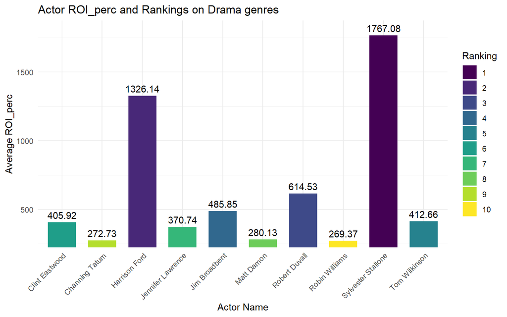

```r
# Create a bar chart with scaled y-axis and rotated x-axis labels
bar_chart_scaled <- ggplot(actor_ranking_table_roi, aes(x = actor_1_name, y = roi_actor, fill = factor(ranking))) +
  geom_bar(stat = "identity", position = "dodge", width = 0.7) +
  geom_text(aes(label = sprintf("%.2f", roi_actor), y = roi_actor), vjust = -0.5) +  # Add value labels
  scale_fill_viridis_d() +
  labs(
    title = "Actor ROI_perc and Rankings on Drama genres",
    x = "Actor Name",
    y = "Average ROI_perc",
    fill = "Ranking"
  ) +
  theme_minimal() +
  coord_cartesian(ylim = c(300, 1800)) +  # Set y-axis limit
  theme(axis.text.x = element_text(angle = 45, hjust = 1))  # Rotate x-axis labels

# Display the scaled bar chart
print(bar_chart_scaled)
```

## Comedy Table

Cal the actor ROI

Actor ranking Table

| actor_1_name | roi_actor | ranking |
| --- | --- | --- |
| Matt Damon | 807.2004 | 1 |
| Macaulay Culkin | 537.1181 | 2 |
| Tom Wilkinson | 354.1954 | 3 |
| Channing Tatum | 327.4740 | 4 |
| Morgan Freeman | 312.6348 | 5 |
| Joseph Gordon-Levitt | 303.9677 | 6 |

Create bar chart

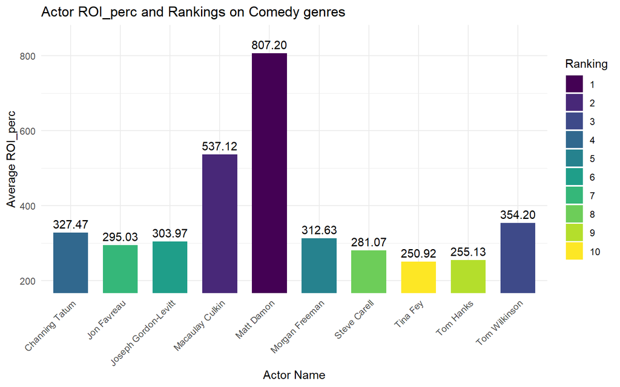

```r
# Create a bar chart with scaled y-axis and rotated x-axis labels
bar_chart_scaled <- ggplot(actor_ranking_table_roi, aes(x = actor_1_name, y = roi_actor, fill = factor(ranking))) +
  geom_bar(stat = "identity", position = "dodge", width = 0.7) +
  geom_text(aes(label = sprintf("%.2f", roi_actor), y = roi_actor), vjust = -0.5) +  # Add value labels
  scale_fill_viridis_d() +
  labs(
    title = "Actor ROI_perc and Rankings on Comedy genres",
    x = "Actor Name",
    y = "Average ROI_perc",
    fill = "Ranking"
  ) +
  theme_minimal() +
  coord_cartesian(ylim = c(200, 850)) +  # Set y-axis limit
  theme(axis.text.x = element_text(angle = 45, hjust = 1))  # Rotate x-axis labels

# Display the scaled bar chart
print(bar_chart_scaled)
```

## Thriller Table

Cal the actor ROI

Actor ranking Table

| actor_1_name | roi_actor | ranking |
| --- | --- | --- |
| Jennifer Lawrence | 238.88963 | 1 |
| Jake Gyllenhaal | 160.34611 | 2 |
| Don Cheadle | 114.43058 | 3 |
| Harrison Ford | 110.04085 | 4 |
| Tom Cruise | 80.13566 | 5 |
| Anthony Hopkins | 77.99363 | 6 |

Create bar chart

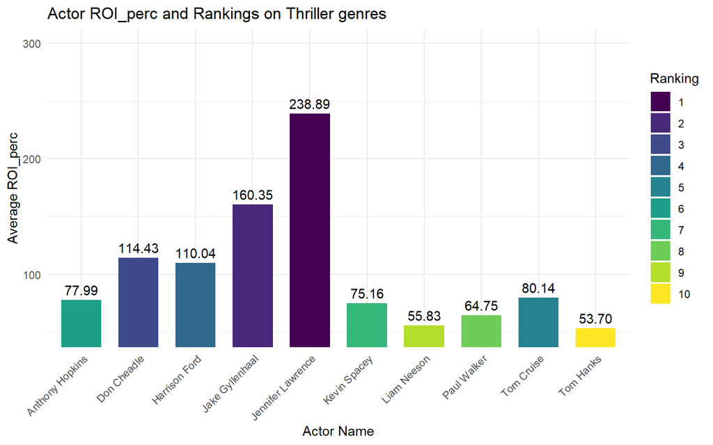

```r
# Create a bar chart with scaled y-axis and rotated x-axis labels
bar_chart_scaled <- ggplot(actor_ranking_table_roi, aes(x = actor_1_name, y = roi_actor, fill = factor(ranking))) +
  geom_bar(stat = "identity", position = "dodge", width = 0.7) +
  geom_text(aes(label = sprintf("%.2f", roi_actor), y = roi_actor), vjust = -0.5) +  # Add value labels
  scale_fill_viridis_d() +
  labs(
    title = "Actor ROI_perc and Rankings on Thriller genres",
    x = "Actor Name",
    y = "Average ROI_perc",
    fill = "Ranking"
  ) +
  theme_minimal() +
  coord_cartesian(ylim = c(50, 300)) +  # Set y-axis limit
  theme(axis.text.x = element_text(angle = 45, hjust = 1))  # Rotate x-axis labels

# Display the scaled bar chart
print(bar_chart_scaled)
```